# Intro to the unvotes package

David Robinson

2017-06-18

This package provides the voting history of countries in the [United Nations General Assembly](http://www.un.org/en/ga/), along with information such as date, description, and topics for each vote.

### Datasets

The unvotes contains three datasets, each data frames (specifically tbl_dfs, which are more convenient to print). First is the history of each country’s vote. These are represented in the `un_votes` dataset, with one row for each country/vote pair:

```r
library(dplyr)
library(unvotes)

un_votes
```

```
## # A tibble: 738,764 x 4
##     rcid                  country country_code   vote
##    <int>                    <chr>        <chr> <fctr>
##  1     3 United States of America           US    yes
##  2     3                   Canada           CA     no
##  3     3                     Cuba           CU    yes
##  4     3                    Haiti           HT    yes
##  5     3       Dominican Republic           DO    yes
##  6     3                   Mexico           MX    yes
##  7     3                Guatemala           GT    yes
##  8     3                 Honduras           HN    yes
##  9     3              El Salvador           SV    yes
## 10     3                Nicaragua           NI    yes
## # ... with 738,754 more rows
```

The package also contains a dataset of information about each roll call vote, including the date, description, and relevant resolution that was voted on:

```r
un_roll_calls
```

```
## # A tibble: 5,429 x 9
##     rcid session importantvote       date   unres amend  para
##    <int>   <dbl>         <dbl>     <date>   <chr> <dbl> <dbl>
##  1     3       1             0 1946-01-01  R/1/66     1     0
##  2     4       1             0 1946-01-02  R/1/79     0     0
##  3     5       1             0 1946-01-04  R/1/98     0     0
##  4     6       1             0 1946-01-04 R/1/107     0     0
##  5     7       1             0 1946-01-02 R/1/295     1     0
##  6     8       1             0 1946-01-05 R/1/297     1     0
##  7     9       1             0 1946-02-05 R/1/329     0     0
##  8    10       1             0 1946-02-05 R/1/361     1     1
##  9    11       1             0 1946-02-05 R/1/376     0     0
## 10    12       1             0 1946-02-06 R/1/394     1     1
## # ... with 5,419 more rows, and 2 more variables: short <chr>, descr <chr>
```

Finally, the `un_roll_call_issues` dataset shows relationships betwen each vote and 6 issues:

```r
un_roll_call_issues
```

```
## # A tibble: 5,281 x 3
##     rcid short_name                issue
##    <int>      <chr>                <chr>
##  1  3372         me Palestinian conflict
##  2  3658         me Palestinian conflict
##  3  3692         me Palestinian conflict
##  4  2901         me Palestinian conflict
##  5  3020         me Palestinian conflict
##  6  3217         me Palestinian conflict
##  7  3298         me Palestinian conflict
##  8  3429         me Palestinian conflict
##  9  3558         me Palestinian conflict
## 10  3625         me Palestinian conflict
## # ... with 5,271 more rows
```

```r
library(dplyr)
count(un_roll_call_issues, issue, sort = TRUE)
```

```
## # A tibble: 6 x 2
##                                  issue     n
##                                  <chr> <int>
## 1                 Palestinian conflict  1104
## 2                          Colonialism   991
## 3                         Human rights   986
## 4         Arms control and disarmament   956
## 5 Nuclear weapons and nuclear material   762
## 6                 Economic development   482
```

(Use `help()` to get information and documentation about each dataset).

### Example analysis

Many useful analyses will first involve joining the vote and roll call datasets by the shared `rcid` (roll call ID) column:

```r
library(dplyr)

joined <- un_votes %>%
  inner_join(un_roll_calls, by = "rcid")

joined
```

```
## # A tibble: 738,764 x 12
##     rcid                  country country_code   vote session
##    <int>                    <chr>        <chr> <fctr>   <dbl>
##  1     3 United States of America           US    yes       1
##  2     3                   Canada           CA     no       1
##  3     3                     Cuba           CU    yes       1
##  4     3                    Haiti           HT    yes       1
##  5     3       Dominican Republic           DO    yes       1
##  6     3                   Mexico           MX    yes       1
##  7     3                Guatemala           GT    yes       1
##  8     3                 Honduras           HN    yes       1
##  9     3              El Salvador           SV    yes       1
## 10     3                Nicaragua           NI    yes       1
## # ... with 738,754 more rows, and 7 more variables: importantvote <dbl>,
## #   date <date>, unres <chr>, amend <dbl>, para <dbl>, short <chr>,
## #   descr <chr>
```

One could then count how often each country votes “yes” on a resolution in each year:

```r
library(lubridate)

by_country_year <- joined %>%
  group_by(year = year(date), country) %>%
  summarize(votes = n(),
            percent_yes = mean(vote == "yes"))

by_country_year
```

```
## # A tibble: 9,689 x 4
## # Groups:   year [?]
##     year                          country votes percent_yes
##    <dbl>                            <chr> <int>       <dbl>
##  1  1946                      Afghanistan    17   0.4117647
##  2  1946                        Argentina    43   0.6976744
##  3  1946                        Australia    43   0.5581395
##  4  1946                          Belarus    43   0.4418605
##  5  1946                          Belgium    43   0.6046512
##  6  1946 Bolivia (Plurinational State of)    43   0.6976744
##  7  1946                           Brazil    43   0.6046512
##  8  1946                           Canada    42   0.6428571
##  9  1946                            Chile    43   0.6046512
## 10  1946                         Colombia    42   0.3095238
## # ... with 9,679 more rows
```

After which this can be visualized for one or more countries:

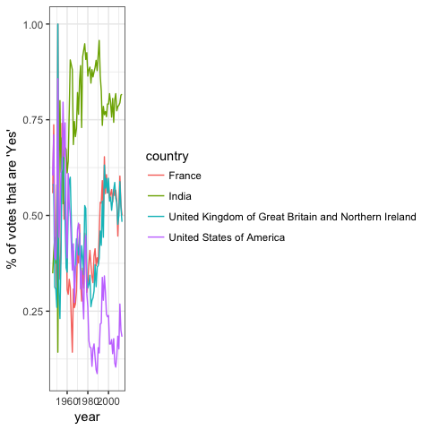

```r
library(ggplot2)
theme_set(theme_bw())

countries <- c("United States of America", "United Kingdom of Great Britain and Northern Ireland", "India", "France")

# there were fewer votes in 2013
by_country_year %>%
  filter(country %in% countries, year <= 2013) %>%
  ggplot(aes(year, percent_yes, color = country)) +
  geom_line() +
  ylab("% of votes that are 'Yes'")
```

Similarly, we could look at how the voting record of the United States has changed on each of the issues by joining with the `un_roll_call_issues` dataset:

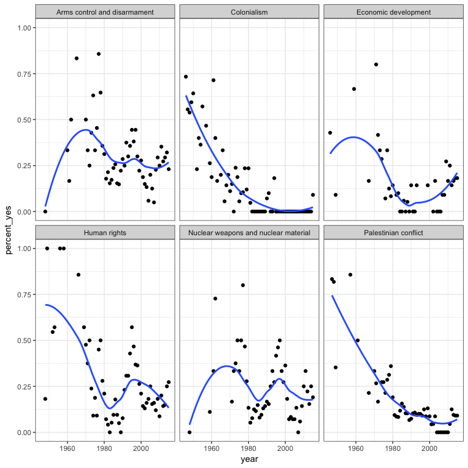

```r
joined %>%
  filter(country == "United States of America") %>%
  inner_join(un_roll_call_issues, by = "rcid") %>%
  group_by(year = year(date), issue) %>%
  summarize(votes = n(),
            percent_yes = mean(vote == "yes")) %>%
  filter(votes > 5) %>%
  ggplot(aes(year, percent_yes)) +
  geom_point() +
  geom_smooth(se = FALSE) +
  facet_wrap(~ issue)
```